# Économétrie M1 MBFA avec `R`

Antoine Terracol

# Introduction, `R`, RStudio et RStudio Cloud

Les applications de ce cours se baseront en grande partie sur le logiciel libre et gratuit `R`. Il faut donc que vous soyez en mesure de l’utiliser vous même.

`R` est à la fois un language de programmation et un logiciel de calcul statistique. Il est *gratuit* et *libre* (*open-source*). Pour commencer, vous allez devoir installer deux logiciels :

1. [`R`, le language de programmation lui même.](https://www.r-project.org)
   - Sélectionnez votre système d’exploitation et choisissez la version la plus récente de `R`
2. [RStudio, une excellente interface de programmation pour `R`.](http://www.rstudio.com/)
   - Attention, il faut que vous ayez installé `R` pour pouvoir utiliser RStudio. RStudio est juste une interface permettant d’utiliser `R’.

Les éditeurs du logiciel RStudio ont par ailleurs crée la plate-forme en ligne [RStudio Cloud rstudio.cloud.](https://www.rstudio.cloud). Cette dernière permet d’utiliser `R` en ligne depuis son navigateur, de faire des tutoriels d’introduction (voire plus avancés), etc. Afin de vous familiariser au plus vite avec le `R` et RStudio (pour ceux qui ne connaissent pas déjà `R`), il faut *au plus vite* que

1. Vous vous rendiez sur [rstudio.cloud.](https://www.rstudio.cloud) et que vous vous y créiez un compte (*Sign Up*). La plateforme est en anglais mais ça devrait être compréhensible
2. Une fois votre compté crée, allez sur la page des *Primers* (tutoriels d’itroduction) : https://rstudio.cloud/learn/primers, et effectuez **au minimum** les tutoriels “*The Basics*” et “*Work with Data*”. Idéalement effectuez aussi “*Visualize Data*” et “*Tidy Your Data*”. Les plus courageux/motivés pourront également effectuer “*Iterate*” et “*Write Functions*”.

R Studio Cloud vous permet également d’utiliser `R` en ligne depuis un navigateur sans avoir à l’installer sur votre machine. C’est extrêmement pratique, mais la version gratuite ne permet que 15 heures d’utilisation par mois pour chaque compte. Son utilisation sera donc réservée aux éventuels cours dans une salle informatique et pour ceux d’entre vous qui sont dans l’impossibilité d’installer `R` sur leur ordinateur.

Dans la mesure du possible, venez avec votre machine en cours.

# Simulations Monte-Carlo

Dans ce cours, nous allons régulièrement faire des *simulations de Monte-Carlo* afin d’étudier les propriétés des estimateurs que nous rencontrerons. Ces propriétés (biais, convergence, efficacité etc.) sont des propriétés *statistques* qui ont trait à la *distribution* des estimateurs, vus comme une variables aléatoire. Une simulation de Monte Carlo consiste en quelque sortes à tirer plein de valeurs de ces variables aléatoires afin d’étudier leurs distribution.

## un exemple

Votre cours de statistrique et de probabilité vous a (normalement) appris que la moyenne d’un échantillon de taille $n$ issu d’une loi Normale $N(\mu,\sigma^2)$ de moyenne $\mu$ et d’écart-type $\sigma$ est une variable aléatoire suivant une loi normale de moyenne $\mu$ et d’écart-type $\frac{\sigma}{\sqrt{n}}$. Utilisons `R’ pour le vérifier.

Commençons par calculer la moyenne d’un échantillon de 100 tirages d’une $N(0,1)$

```r
n <- 100
mu <- 0
sigma <- 1
x <- rnorm(n,mean=mu,sd=sigma)
mean(x)
```

```
## [1] -0.08365639
```

On voit que la moyenne des 100 tirages n’est pas strictement égale à 0, et on ne voit pas bien comment juger de l’écart-type ou de la loi de probabilité de cette moyenne. Si on lance le code une seconde fois, le résultat va d’ailleurs changer :

```r
n <- 100
mu <- 0
sigma <- 1
x <- rnorm(n,mean=mu,sd=sigma)
mean(x)
```

```
## [1] 0.116541
```

```r
K <- 10000 # On va faire 10000 réplications, on aura donc 10000 moyennes
n <- 100
mu <- 0
sigma <- 1
moyennes <- c() # On crée un vecteur vide qui contiendra les K moyennes
for (i in 1:K) { # on initialise la boucle
  x <- rnorm(n,mean=mu,sd=sigma) # on tire l'ééchantillon
  moyennes[i] <- mean(x) # on stocke la moyenne issue de la ième réplication à
                          # la ième position du vecteur "moyennes"
}
moyennes[1:10] # on affiche les 10 premières moyennes
```

```
##  [1]  0.02588758 -0.09081159  0.10219075  0.12347387 -0.01410517  0.09624245
##  [7]  0.17897709 -0.11201445 -0.01814170  0.02042692
```

```r
mean(moyennes) # moyenne des moyennes (0 en théorie)
```

```
## [1] -0.0003853752
```

```r
sd(moyennes) # écart-type des moyennes (1/sqrt(n) en théorie)
```

```
## [1] 0.09948225
```

```r
1/sqrt(n) # valeur de 1/sqrt(n)
```

```
## [1] 0.1
```

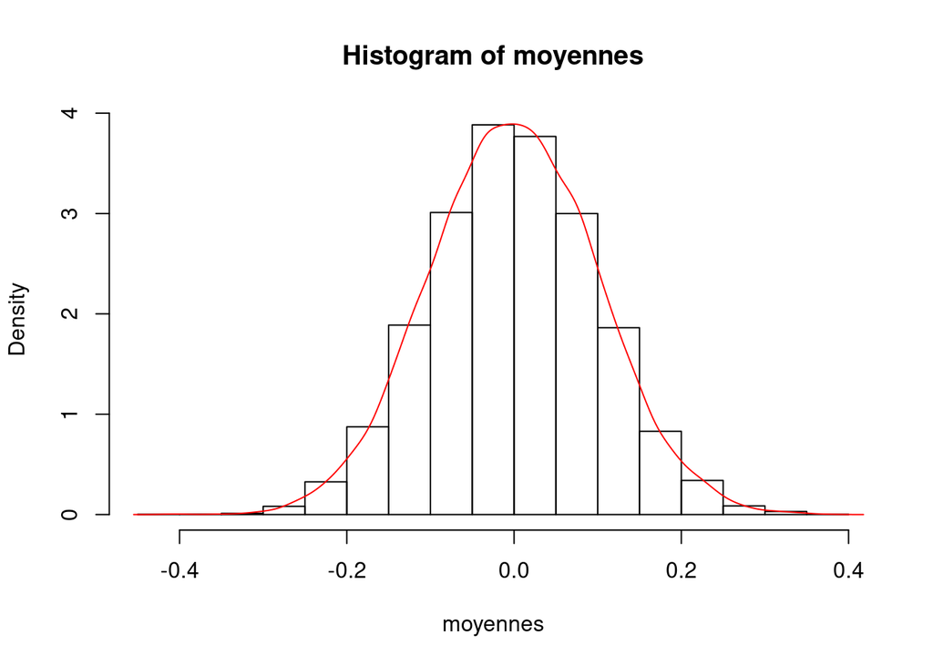

```r
hist(moyennes,prob=TRUE) # on trace l'histogramme des moyennes
lines(density(moyennes),col="red") # on y ajoute le tracé de la densité des moyennes
```

Ceux qui ont suivi le tutoriel “*Visualize Data*” peuvent utiliser les outils graphiques du package `ggplot2`

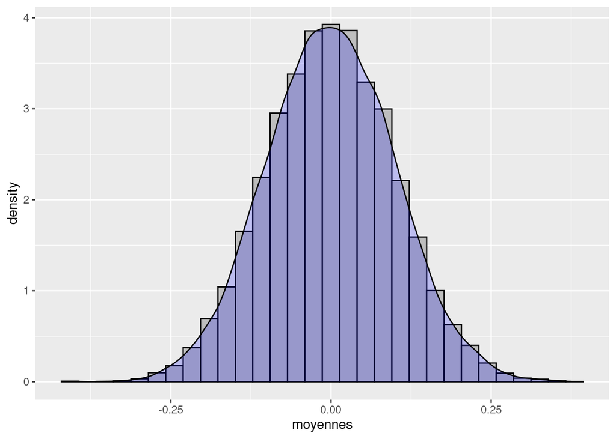

```r
library(ggplot2)
ggplot(mapping=aes(x=moyennes)) +
         geom_histogram(aes(y=..density..),fill="grey",color="black") +
          geom_density(fill="blue",alpha=0.2)
```

NB : le `y=..density..` indique à `geom_histogram` d’utiliser la densité en ordonnées, au lieu de la fréquence. Ça permet d’avoir l’histogramme et la courbe des densité à la même échelle.

On constate que 1. La moyenne des K=10000 moyennes est très proche de la moyenne théorique (0) 2. L’écart-type des K moyennes est très proche de l’écart-type théorique (0.1) 3. La distribution est proche de celle d’une loi normale

# Généralisation : le package MonteCarlo

L’exemple précédent a montré que l’on pouvait assez facilement effectuer une simulation basique avec du code assez simple. Néanmoins, ce code ne permet de simuler qu’un seul scénario (valeurs de $n$, de $\mu$ et de $\sigma$) à la fois. Si on souhaite voir ce qu’il se passe lorsqu’on fait varier les paramètres de la simulation, il faudrait copier-coller le code de nombreuses fois et modifer à chaque fois les paramètres. De plus, il faudrait faire attention à sauvegarder les résultats dans des vecteurs différents à chaque fois. Afin de s’éviter ces désagréments, le package MonteCarlo permet d’automatiser ces tâches pour nous.

On commence par charger le package `MonteCarlo` ainsi que `tidyverse` (voir les tutoriels)

```r
library(MonteCarlo) # doit avoir package Rcpp installé
library(tidyverse) # charge plein d'outils utiles, voir les tutoriels sur rstudio.cloud
```

On définit ensuite une fonction qui va effectuer le tirage de l’échantillon aléatoire, calculer la moyenne, et retourner le résultat :

```r
simul_moyenne <- function(n,mu,sigma) { # Notre fonction s'appelle "simul_moyenne" et prend les
                                        # arguments n, mu et sigma
  tirages <- rnorm(n,mean=mu,sd=sigma) # on effectue le tirage aléatoire avec les valeurs données en argument
  moy <- mean(tirages) # on calcule la moyenne
  return(list("moyenne"=moy)) # on la retourne dans une liste nommée "moyenne"
}
```

On définit ensuite des vecteurs qui vont définir l’ensemble des “scénarios” de simulations, c’est à dire les valeurs des paramètres que l’ont veut faire varier. Ici on veut deux valeurs pour la taille d’échantillon, deux valeurs pour l’espérance, et trois pour l’écart-type

```r
n_grid <- c(10,100)
mu_grid <- c(0, 5)
sigma_grid <- c(1, 2, 4)
```

On indique ensuite que le programme devra passer toutes les combinaisons de ces valeurs en tant qu’arguments à notre fonction “simul_moyenne”

```r
param_list=list("n"=n_grid, "mu"=mu_grid, "sigma"=sigma_grid)
```

On peut maintenant lancer `MonteCarlo` en lui indiquant quelle fonction utiliser, le nombre de réplications par scénario, et où trouver la liste des paramètres. On stocke les résultats dans un objet nommé “résultats”

```r
resultats<-MonteCarlo(func=simul_moyenne, nrep=10000, param_list=param_list)
```

Regardons ce que l’objet “résultats” contient :

```r
summary(resultats)
```

```
## Simulation of function:
##
## function(n,mu,sigma) { # Notre fonction s'appelle "simul_moyenne" et prend les
##                                         # arguments n, mu et sigma
##   tirages <- rnorm(n,mean=mu,sd=sigma) # on effectue le tirage aléatoire avec les valeurs données en argument
##   moy <- mean(tirages) # on calcule la moyenne
##   return(list("moyenne"=moy)) # on la retourne dans une liste nommée "moyenne"
## }
## <bytecode: 0x562894f15128>
##
## Required time: 1.86 secs for nrep = 10000  repetitions on 1 CPUs
##
## Parameter grid:
##
##      n : 10 100
##     mu : 0 5
##  sigma : 1 2 4
##
##
## 1 output arrays of dimensions: 2 2 3 10000
```

On va le transformer les parties pertinentes en `data frame` (voir les tutoriels) pour une manipulation plus aisée. la fonction `head()` permet ensuite de lister les premières lignes d’une `data frame`, afin de vérifier rapidement son contenu.

```r
data_resultats <-MakeFrame(resultats)
head(data_resultats)
```

```
##     n mu sigma     moyenne
## 1  10  0     1 0.380283977
## 2 100  0     1 0.001196441
## 3  10  5     1 5.067302716
## 4 100  5     1 4.962591853
## 5  10  0     2 0.043048160
## 6 100  0     2 0.140917216
```

On va maintenant calculer les moyennes et écart-types des 10000 moyennes calculées pour chaque scénario de simulation. On fait appel aux outils de “pipe” (`%>%`) et de groupe (`group_by()`) expliqués dans le tutoriel “*Work With Data*”. On en profite pour ajouter une variable “ecty_theor” donnant l’écart-type théorique de la distribution des moyennes

```r
data_resultats %>%
mutate(ecty_theor=sigma/sqrt(n)) %>%
group_by(n,mu,sigma) %>%
  summarise(moy=mean(moyenne),ecty=sd(moyenne),ecty_theor=mean(ecty_theor))
```

```
## # A tibble: 12 x 6
## # Groups:   n, mu [4]
##        n    mu sigma       moy   ecty ecty_theor
##    <dbl> <dbl> <dbl>     <dbl>  <dbl>      <dbl>
##  1    10     0     1 -0.00282  0.316       0.316
##  2    10     0     2 -0.000376 0.641       0.632
##  3    10     0     4 -0.00805  1.27        1.26
##  4    10     5     1  5.00     0.314       0.316
##  5    10     5     2  4.99     0.628       0.632
##  6    10     5     4  4.99     1.26        1.26
##  7   100     0     1 -0.00128  0.0994      0.1
##  8   100     0     2 -0.000343 0.201       0.2
##  9   100     0     4 -0.00301  0.402       0.4
## 10   100     5     1  5.00     0.100       0.1
## 11   100     5     2  5.00     0.199       0.2
## 12   100     5     4  5.00     0.400       0.4
```

On constate que la moyenne des moyenne (colonne “moy”) est très proche de la moyenne théorique (“mu”), de même que l’écart-type de la distribution des moyennes (“ecty”) est très proche de l’écart-type théorique. Nos observations semblent bien coller avec la théorie.

On complète l’exercice en faisant un graphique de la fonction de densité estimées de nos résultats, pour chaque valeur de $n$, $\mu$ et $\sigma$.

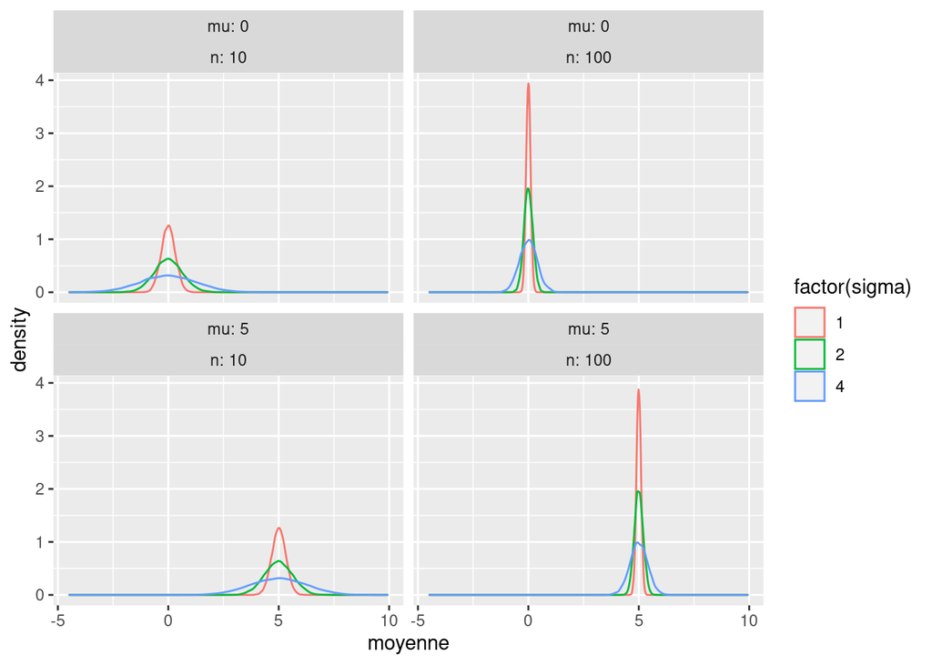

```r
ggplot(data=data_resultats,mapping=aes(x=moyenne,group=sigma,color=factor(sigma))) +
  geom_density() +
  facet_wrap(mu ~ n,labeller=label_both)
```

# Avec une régression par MCO

`R` permet de faire une régression linéaire par MCO avec la commande `lm()`

On va charger une base de données préinstallée avec `R` : les données “mtcars”

```r
data(mtcars)
head(mtcars)
```

```
##                    mpg cyl disp  hp drat    wt  qsec vs am gear carb
## Mazda RX4         21.0   6  160 110 3.90 2.620 16.46  0  1    4    4
## Mazda RX4 Wag     21.0   6  160 110 3.90 2.875 17.02  0  1    4    4
## Datsun 710        22.8   4  108  93 3.85 2.320 18.61  1  1    4    1
## Hornet 4 Drive    21.4   6  258 110 3.08 3.215 19.44  1  0    3    1
## Hornet Sportabout 18.7   8  360 175 3.15 3.440 17.02  0  0    3    2
## Valiant           18.1   6  225 105 2.76 3.460 20.22  1  0    3    1
```

Effectuons une régression linaire de, par exemple, “mpg” sur “cyl” et “disp”

```r
lm(data=mtcars,mpg ~ cyl + disp)
```

```
##
## Call:
## lm(formula = mpg ~ cyl + disp, data = mtcars)
##
## Coefficients:
## (Intercept)          cyl         disp
##    34.66099     -1.58728     -0.02058
```

La sortie est assez minimale. Stockons cette régression dans un objet que nous appellerons “ma_regression” et faisons un `summary()` de ce dernier

```r
ma_regression <- lm(data=mtcars,mpg ~ cyl + disp)
summary(ma_regression)
```

```
##
## Call:
## lm(formula = mpg ~ cyl + disp, data = mtcars)
##
## Residuals:
##     Min      1Q  Median      3Q     Max
## -4.4213 -2.1722 -0.6362  1.1899  7.0516
##
## Coefficients:
##             Estimate Std. Error t value Pr(>|t|)
## (Intercept) 34.66099    2.54700  13.609 4.02e-14 ***
## cyl         -1.58728    0.71184  -2.230   0.0337 *
## disp        -0.02058    0.01026  -2.007   0.0542 .
## ---
## Signif. codes:  0 '***' 0.001 '**' 0.01 '*' 0.05 '.' 0.1 ' ' 1
##
## Residual standard error: 3.055 on 29 degrees of freedom
## Multiple R-squared:  0.7596, Adjusted R-squared:  0.743
## F-statistic: 45.81 on 2 and 29 DF,  p-value: 1.058e-09
```

On a déjà plus de détails.

On peut extraire divers éléments issus de `lm()` :

```r
summary(ma_regression)$coef[,"Estimate"] # les beta chapeau
```

```
## (Intercept)         cyl        disp
## 34.66099474 -1.58727681 -0.02058363
```

```r
summary(ma_regression)$coef[,"Std. Error"] # les écarts-type
```

```
## (Intercept)         cyl        disp
##  2.54700388  0.71184427  0.01025748
```

```r
summary(ma_regression)$coef[,"Estimate"]["cyl"] # le beta chapeau de la variable "cyl"
```

```
##       cyl
## -1.587277
```

```r
summary(ma_regression)$coef[,"Estimate"][["cyl"]] # la même valeur, mais sans le nom associé, notez les doubles crochets
```

```
## [1] -1.587277
```

On va maintenant utiliser ces éléments pour construire une simulation de Monte-Carlo de la distribution de l’estimateur des MCO $\hat\beta_x$ dans un cadre qui respecte les hypothèses de Gauss-Markov

```r
library(MonteCarlo) # doit avoir package Rcpp installé
library(tidyverse)

betareg<-function(n) {
  x <- rnorm(n,mean=0,sd=1)
  epsilon <- rnorm(n,mean=0,sd=1) # epsilon suit une loi normale non corrélée à x
  y <- 1+x+epsilon
  mareg <- lm(y~x)
  coeffs <- summary(mareg)$coef[,"Estimate"]
  betax <- coeffs[["x"]]
  return(list("betax"=betax))
}

n_grid<-c(10,100)

param_list=list("n"=n_grid)
```

```r
resultats<-MonteCarlo(func=betareg, nrep=10000, param_list=param_list)
```

```r
summary(resultats)
```

```
## Simulation of function:
##
## function(n) {
##   x <- rnorm(n,mean=0,sd=1)
##   epsilon <- rnorm(n,mean=0,sd=1) # epsilon suit une loi normale non corrélée à x
##   y <- 1+x+epsilon
##   mareg <- lm(y~x)
##   coeffs <- summary(mareg)$coef[,"Estimate"]
##   betax <- coeffs[["x"]]
##   return(list("betax"=betax))
## }
## <bytecode: 0x562897104750>
##
## Required time: 17.36 secs for nrep = 10000  repetitions on 1 CPUs
##
## Parameter grid:
##
##  n : 10 100
##
##
## 1 output arrays of dimensions: 2 10000
```

```r
data_resultats <-MakeFrame(resultats)
head(data_resultats)
```

```
##     n     betax
## 1  10 0.9500756
## 2 100 1.1047499
## 3  10 1.2519415
## 4 100 1.0256387
## 5  10 1.1687762
## 6 100 0.7896912
```

```r
data_resultats %>%
  group_by(n) %>%
  summarise(moy=mean(betax),ecty=sd(betax))
```

```
## # A tibble: 2 x 3
##       n   moy  ecty
##   <dbl> <dbl> <dbl>
## 1    10  1.00 0.377
## 2   100  1.00 0.102
```

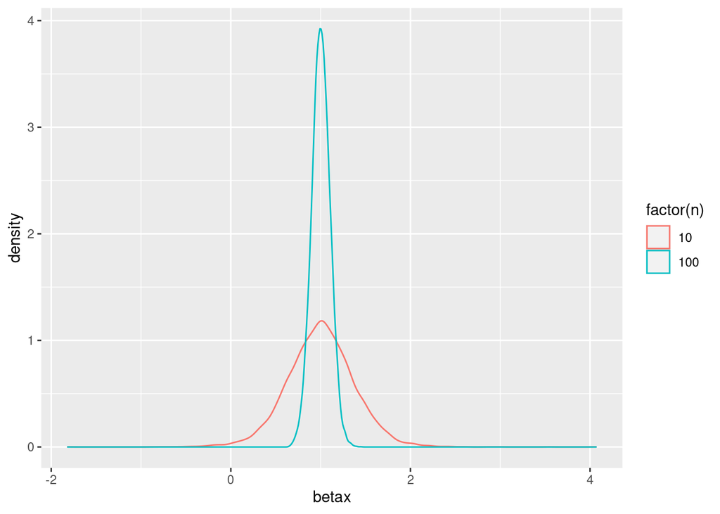

```r
ggplot(data=data_resultats,mapping=aes(x=betax,group=n,color=factor(n)))+geom_density()
```

Les résultats ci-dessus sont-ils ceux que l’on s’attendais à avoir ? Que nous dit la théorie ?